# Snail Kite Population Viability Analysis with State-Space models

```r
# I am going to leave it as a matrix of ps in case we want to make them
# time dependent later
phats <- matrix(nrow=15, ncol=28)
row.names(phats) <- wet.names
for(i in 1:15){
  subdat <- all.ps[all.ps$stratum==sub("_.*", "", wet.names)[i],]
  phats[i,] <- subdat$estimate
}
```

The number of (sub)populations `p` now is defined as the 15 wetlands, and included in the initial values lists. This is a trick to have the priors in the positive domain of the lognormal distribution.

```r
p <- nrow(S4mat)
myinits <- list(lmuvec = log(rep(naive.guess[1],p)), # mu ≈ mean(log(ts.4guess)),
                lthetavec = log(rep(naive.guess[2],p)), # why theta in log?
                lsigmasq = log(naive.guess[3])) # why sigmasq in log?
```

We next define the “dinvmat” choosing one of the distance matrices. This is the inverse matrix of distances, because in our model, the effect of one region on the growth rate of another region will be made inversely proportional to their mutual geographical distance.

```r
dmat <- wet.dists
dinvmat <- (dmat/dmat^2)
dinvmat[is.na(dinvmat)] <- 0
dinvmat
```

```
##                             EAST_Grassy.Waters.Preserve EVER_WCA.3A EVER_WCA.2B
## EAST_Grassy.Waters.Preserve                 0.000000000 0.010920464 0.014584595
## EVER_WCA.3A                                 0.010920464 0.000000000 0.032219110
## EVER_WCA.2B                                 0.014584595 0.032219110 0.000000000
## EVER_Loxahatchee.NWR                        0.029499407 0.017311540 0.027744902
## EVER_WCA.3B                                 0.009435786 0.040473654 0.026484974
## EVER_Everglades.NP                          0.005857888 0.012395295 0.009686898
## EVER_STA1E                                  0.050679480 0.013658891 0.018721432
## KRV_East.Lake.Tohopekaliga                  0.004974088 0.003933317 0.003982430
## KRV_Lake.Kissimmee                          0.006041653 0.004715781 0.004747107
## KRV_Lake.Istokpoga                          0.007785738 0.006360232 0.006241248
## KRV_Lake.Hatchineha                         0.005415421 0.004369105 0.004373996
## KRV_Lake.Tohopekaliga                       0.005040325 0.004046448 0.004072519
## OKEE_Lake.Okeechobee                        0.014663110 0.010235511 0.010443341
## PP_Paynes.Prairie                           0.002669296 0.002373718 0.002370318
## SJM_SJM                                     0.007989757 0.005217021 0.005482782
##                             EVER_Loxahatchee.NWR EVER_WCA.3B EVER_Everglades.NP
## EAST_Grassy.Waters.Preserve          0.029499407 0.009435786        0.005857888
## EVER_WCA.3A                          0.017311540 0.040473654        0.012395295
## EVER_WCA.2B                          0.027744902 0.026484974        0.009686898
## EVER_Loxahatchee.NWR                 0.000000000 0.013773283        0.007304332
## EVER_WCA.3B                          0.013773283 0.000000000        0.015246439
## EVER_Everglades.NP                   0.007304332 0.015246439        0.000000000
## EVER_STA1E                           0.057512888 0.011160331        0.006524443
## KRV_East.Lake.Tohopekaliga           0.004557676 0.003594611        0.003062837
## KRV_Lake.Kissimmee                   0.005541254 0.004232793        0.003529695
## KRV_Lake.Istokpoga                   0.007433501 0.005499582        0.004435669
## KRV_Lake.Hatchineha                  0.005024575 0.003948595        0.003350181
## KRV_Lake.Tohopekaliga                0.004653898 0.003685400        0.003146036
## OKEE_Lake.Okeechobee                 0.014478253 0.008236915        0.005760789
## PP_Paynes.Prairie                    0.002552606 0.002242979        0.002053326
## SJM_SJM                              0.006754447 0.004674869        0.003707981
##                              EVER_STA1E KRV_East.Lake.Tohopekaliga
## EAST_Grassy.Waters.Preserve 0.050679480                0.004974088
## EVER_WCA.3A                 0.013658891                0.003933317
## EVER_WCA.2B                 0.018721432                0.003982430
## EVER_Loxahatchee.NWR        0.057512888                0.004557676
## EVER_WCA.3B                 0.011160331                0.003594611
## EVER_Everglades.NP          0.006524443                0.003062837
## EVER_STA1E                  0.000000000                0.004897841
```

[output cut: 41 more lines]

```
## EAST_Grassy.Waters.Preserve          0.014663110       0.002669296 0.007989757
## EVER_WCA.3A                          0.010235511       0.002373718 0.005217021
## EVER_WCA.2B                          0.010443341       0.002370318 0.005482782
## EVER_Loxahatchee.NWR                 0.014478253       0.002552606 0.006754447
## EVER_WCA.3B                          0.008236915       0.002242979 0.004674869
## EVER_Everglades.NP                   0.005760789       0.002053326 0.003707981
## EVER_STA1E                           0.016943013       0.002651907 0.007604672
## KRV_East.Lake.Tohopekaliga           0.006376338       0.005759657 0.012632970
## KRV_Lake.Kissimmee                   0.008670377       0.004730536 0.017596562
## KRV_Lake.Istokpoga                   0.015260393       0.003786649 0.013470261
## KRV_Lake.Hatchineha                  0.007519014       0.005174289 0.013527501
## KRV_Lake.Tohopekaliga                0.006649626       0.005652626 0.012434064
## OKEE_Lake.Okeechobee                 0.000000000       0.003065207 0.010364785
## PP_Paynes.Prairie                    0.003065207       0.000000000 0.003973007
## SJM_SJM                              0.010364785       0.003973007 0.000000000
```

Bundle the data cloning fit

```r
data4dclone <- list(K=1,
                    N4=dcdim(array(S4mat,dim=c(p,ncol(S4mat),1))),
                    N5=dcdim(array(S5mat,dim=c(p,ncol(S5mat),1))),
                    N6=dcdim(array(S6mat,dim=c(p,ncol(S6mat),1))),
                    W = W^2, # testing quadratic
                    detectp = phats,
                    qp1=ncol(S4mat),
                    p=p,
                    mupmean=rep(6,p),
                    muprec=(1/3)*diag(p),
                    lthetamean = rep(0.5,p),
                    lthetaprec =  10*diag(p),
                    Ip =  diag(p),
                    dinvmat = dinvmat,
                    step.stone = matrix(c(1,7,
                                          2,5, 3,2, 4,7, 5,2, 6,5, 7,4,
                                          8,12, 9,11, 10,9, 11,9, 12,8,
                                          13,7,
                                          14,8,
                                          15,9),
                                        nrow=15,ncol=2,byrow=TRUE)
)
```

Setup the data cloning model fit with wather and annual detection probability

```r
cl.seq <- c(1,20);
n.iter<-100000;n.adapt<-50000;n.update<-100;thin<-10;n.chains<-3;

out.parms <- c("muvec","cvec","mig.near","mig.far","sigmasq","A",
               "betaw")
mgssdclone_w <- dc.fit(data4dclone,
                     params=out.parms,
                     model=MGSS_DC_w4.0,
                     n.clones=cl.seq,
                     multiply="K",
                     unchanged = c("qp1","p","mupmean","muprec",
                      "step.stone", "lthetamean","lthetaprec", "Ip","dinvmat",
                      "W","detectp"),
                     n.chains = n.chains,
                     n.adapt=n.adapt,
                     n.update=n.update,
                     n.iter = n.iter,
                     thin=thin,
                     inits=myinits)
saveRDS(mgssdclone_w, "Code/mgssdclone_w_phat_quadr.RDS")
```

We can save the MLEs and predict the dynamic of the population for each wetland within six regions with the Kalman filter estimates

```r
mgssdclone_w <- readRDS("Code/mgssdclone_w_phat_quadr.RDS")
mlescentrdist <- summary(mgssdclone_w)[[1]]
mles4kalman <- mlescentrdist[,1]
mles4kalman
```

```
##        A[1]        A[2]        A[3]        A[4]        A[5]        A[6]
##  0.60757243  1.32751552 -0.86056937 -0.19839954 -1.17129705  1.53197463
##        A[7]        A[8]        A[9]       A[10]       A[11]       A[12]
##  0.98936060  0.49808510  1.47346846  0.53887603 -0.50488937  2.42643880
##       A[13]       A[14]       A[15]       betaw     cvec[1]     cvec[2]
##  1.11956117  5.64536892  1.31364856 -0.14450645  0.55156395  0.63359713
##     cvec[3]     cvec[4]     cvec[5]     cvec[6]     cvec[7]     cvec[8]
##  0.90440938  0.54713589  0.89818017  0.19088037  0.42034280  0.49360172
##     cvec[9]    cvec[10]    cvec[11]    cvec[12]    cvec[13]    cvec[14]
##  0.44733524  0.51470405  0.15005180  0.09497199  0.58657155  0.01995905
##    cvec[15]     mig.far    mig.near    muvec[1]    muvec[2]    muvec[3]
##  0.57037571  1.35027795  3.14734912  4.42749217  6.53948276  5.08978137
##    muvec[4]    muvec[5]    muvec[6]    muvec[7]    muvec[8]    muvec[9]
##  3.23879094  2.75504423  2.60333081  4.33187089  4.05403721  4.44985769
##   muvec[10]   muvec[11]   muvec[12]   muvec[13]   muvec[14]   muvec[15]
##  2.89008460  1.29369016  4.39433954  4.86026823  6.06836616  4.92852128
##     sigmasq
##  1.19707273
```

```r
avec4kalman <- mles4kalman[1:15]
beta.4kalman <- mles4kalman[16]
cvec4kalman <- mles4kalman[17:31]
mig.far4kalman <- mles4kalman[32]
mig.near4kalman <- mles4kalman[33]
muvec4kalman <- mles4kalman[34:48]
sigsq4kalman <- mles4kalman[49]
```

## 2.3 Kalman estimates of abundance with effect of assymetric migration

```r
MGSS_KALMANw4.0 <- function(){

  A  <- (Ip - B)%*%muvec
  Sigma <- (1/sigmasq)*Ip

  ##### ---- Likelihood ---- #####
  X[1:p,1] ~ dmnorm(muvec + betaw*W[1:p,1], Sigma)
  for(h in 1:p){
    N4[h,1] ~ dpois(detectp[h,1] * exp(X[h,1]))
    N5[h,1] ~ dpois(detectp[h,1] * exp(X[h,1]))
    N6[h,1] ~ dpois(detectp[h,1] * exp(X[h,1]))
  }
  for( i in 2:qp1){
    ## Process error
    X[1:p,i]  ~ dmnorm(A + betaw*W[1:p,i] + B%*%X[1:p,(i-1)], Sigma);
    for(j in 1:p){
      N4[j,i]  ~ dpois(detectp[j,i] * exp(X[j,i])) ## Observation error
      N5[j,i]  ~ dpois(detectp[j,i] * exp(X[j,i])) ## Observation error
      N6[j,i]  ~ dpois(detectp[j,i] * exp(X[j,i])) ## Observation error
    }
  }
}
```

Data for Kalman estimates

```r
step.stone <- matrix(c(1,7,
                       2,5, 3,2, 4,7, 5,2, 6,5, 7,4,
                       8,12, 9,11, 10,9, 11,9, 12,8,
                       13,7,
                       14,8,
                       15,9),
                     nrow=15,
                     ncol=2,
                     byrow=TRUE)
step.stone
```

```
##       [,1] [,2]
##  [1,]    1    7
##  [2,]    2    5
##  [3,]    3    2
##  [4,]    4    7
##  [5,]    5    2
##  [6,]    6    5
##  [7,]    7    4
##  [8,]    8   12
##  [9,]    9   11
## [10,]   10    9
## [11,]   11    9
## [12,]   12    8
## [13,]   13    7
## [14,]   14    8
## [15,]   15    9
```

```r
B <- matrix(0,p,p)

for(m in 1:p){
  for(n in 1:p){
    B[m,n] <- ifelse((m==n),cvec4kalman[m],
                     ifelse(
      (m==step.stone[m,1])&&(n==step.stone[m,2]),
      dinvmat[m,n]*mig.near4kalman,dinvmat[m,n]*mig.far4kalman)
    ) #

  }
}

print(B) # this is \mathcal{B}, because the diagonal is the `cvec4kalman` (intra-region strength of density dependence)
```

```
##              [,1]        [,2]        [,3]        [,4]        [,5]        [,6]
##  [1,] 0.551563954 0.014745661 0.019693257 0.039832398 0.012740934 0.007909777
##  [2,] 0.014745661 0.633597130 0.043504754 0.023375391 0.127384719 0.016737093
##  [3,] 0.019693257 0.101404788 0.904409376 0.037463329 0.035762076 0.013080004
##  [4,] 0.039832398 0.023375391 0.037463329 0.547135892 0.018597760 0.009862879
##  [5,] 0.012740934 0.127384719 0.035762076 0.018597760 0.898180168 0.020586930
##  [6,] 0.007909777 0.016737093 0.013080004 0.009862879 0.047985865 0.190880368
##  [7,] 0.068431384 0.018443300 0.025279137 0.181013137 0.015069549 0.008809811
##  [8,] 0.006716402 0.005311071 0.005377387 0.006154130 0.004853724 0.004135682
##  [9,] 0.008157911 0.006367615 0.006409914 0.007482233 0.005715447 0.004766070
## [10,] 0.010512910 0.008588081 0.008427419 0.010037292 0.007425965 0.005989386
## [11,] 0.007312323 0.005899506 0.005906111 0.006784573 0.005331701 0.004523675
## [12,] 0.006805839 0.005463830 0.005499032 0.006284055 0.004976315 0.004248023
## [13,] 0.019799274 0.013820784 0.014101413 0.019549666 0.011122125 0.007778667
## [14,] 0.003604291 0.003205179 0.003200589 0.003446727 0.003028645 0.002772560
```

[output cut: 33 more lines]

```r
data4kalman <- list(N4=S4mat,
                    N5=S5mat,
                    N6=S6mat,
                    W = W^2,
                    qp1=ncol(S4mat),
                    p=p,
                    detectp = phats,
                    Ip =  diag(p),
                    betaw = beta.4kalman,
                    muvec = muvec4kalman,
                    sigmasq = sigsq4kalman,
                    B=B
)
str(data4kalman)
```

```
## List of 12
##  $ N4     : num [1:15, 1:28] 3 56 36 3 9 NA NA 27 NA NA ...
##   ..- attr(*, "dimnames")=List of 2
##   .. ..$ : chr [1:15] "EAST_Grassy.Waters.Preserve" "EVER_WCA.3A" "EVER_WCA.2B" "EVER_Loxahatchee.NWR" ...
##   .. ..$ : chr [1:28] "0" "1" "2" "3" ...
##  $ N5     : num [1:15, 1:28] 14 184 47 1 3 NA NA 36 NA NA ...
##   ..- attr(*, "dimnames")=List of 2
##   .. ..$ : chr [1:15] "EAST_Grassy.Waters.Preserve" "EVER_WCA.3A" "EVER_WCA.2B" "EVER_Loxahatchee.NWR" ...
##   .. ..$ : chr [1:28] "0" "1" "2" "3" ...
##  $ N6     : num [1:15, 1:28] 7 93 30 1 0 NA NA 28 NA NA ...
##   ..- attr(*, "dimnames")=List of 2
##   .. ..$ : chr [1:15] "EAST_Grassy.Waters.Preserve" "EVER_WCA.3A" "EVER_WCA.2B" "EVER_Loxahatchee.NWR" ...
##   .. ..$ : chr [1:28] "0" "1" "2" "3" ...
##  $ W      : num [1:15, 1:28] 1.556 0.424 3.21 0.132 0.126 ...
##   ..- attr(*, "dimnames")=List of 2
##   .. ..$ : chr [1:15] "EAST_Grassy.Waters.Preserve" "EVER_WCA.3A" "EVER_WCA.2B" "EVER_Loxahatchee.NWR" ...
##   .. ..$ : chr [1:28] "0" "1" "2" "3" ...
##  $ qp1    : int 28
##  $ p      : int 15
##  $ detectp: num [1:15, 1:28] 0.236 0.236 0.236 0.236 0.236 ...
##   ..- attr(*, "dimnames")=List of 2
##   .. ..$ : chr [1:15] "EAST_Grassy.Waters.Preserve" "EVER_WCA.3A" "EVER_WCA.2B" "EVER_Loxahatchee.NWR" ...
##   .. ..$ : NULL
##  $ Ip     : num [1:15, 1:15] 1 0 0 0 0 0 0 0 0 0 ...
##  $ betaw  : Named num -0.145
##   ..- attr(*, "names")= chr "betaw"
##  $ muvec  : Named num [1:15] 4.43 6.54 5.09 3.24 2.76 ...
##   ..- attr(*, "names")= chr [1:15] "muvec[1]" "muvec[2]" "muvec[3]" "muvec[4]" ...
##  $ sigmasq: Named num 1.2
##   ..- attr(*, "names")= chr "sigmasq"
##  $ B      : num [1:15, 1:15] 0.5516 0.0147 0.0197 0.0398 0.0127 ...
```

And fit the Kalman estimate model

```r
n.iter<-100000
n.adapt<-1000
n.update<-100
thin<-10
n.chains<-3

out.parms <- c("X")
kalman.mcmc.w <- jags.fit(data4kalman,
                         params=out.parms,
                         model=MGSS_KALMANw4.0,
                         n.chains = n.chains,
                         n.adapt=n.adapt,
                         n.update=n.update,
                         n.iter = n.iter,
                         thin=thin)
saveRDS(kalman.mcmc.w, "Code/Kalman_w_quad_phat_OUSS.RDS")
```

And then, bring back the data to see the population trajectories in each region.

```r
kalman.mcmc.w <- readRDS("Code/Kalman_w_quad_phat_OUSS.RDS")
Xkalman.w <-  do.call(rbind, kalman.mcmc.w)

Kalman.quants.w <- apply(Xkalman.w, 2, FUN=function(x){quantile(x, probs=c(0.025,0.5,0.975))})
```

Converting the matrix form to a data frame and extracting the values

```r
kalman_df_w <- as.data.frame(Kalman.quants.w) |>
  mutate(quantile = rownames(Kalman.quants.w)) |>
  pivot_longer(-quantile,
               names_to = "state_time",
               values_to = "value") |>
  extract(state_time,
          into = c("wetland", "time"),
          regex = "X\\[(\\d+),(\\d+)\\]", convert = TRUE)
```

And then plotting with the names of the regions and in real scale of counts, adding the three surveys per year

```r
kalman_wide_w <- kalman_df_w |>
  mutate(value = exp(value),
         wetland = ifelse(wetland == 1, "EAST_Grassy.Waters.Preserve",
                  ifelse(wetland == 2, "EVER_WCA.3A",
                  ifelse(wetland == 3, "EVER_WCA.2B",
                  ifelse(wetland == 4, "EVER_Loxahatchee.NWR",
                  ifelse(wetland == 5, "EVER_WCA.3B",
                  ifelse(wetland == 6, "EVER_Everglades.NP",
                  ifelse(wetland == 7, "EVER_STA1E",
                  ifelse(wetland == 8, "KRV_East.Lake.Tohopekaliga",
                  ifelse(wetland == 9, "KRV_Lake.Kissimmee",
                  ifelse(wetland == 10, "KRV_Lake.Istokpoga",
                  ifelse(wetland == 11, "KRV_Lake.Hatchineha",
                  ifelse(wetland == 12, "KRV_Lake.Tohopekaliga",
                  ifelse(wetland == 13, "OKEE_Lake.Okeechobee",
                  ifelse(wetland == 14, "PP_Paynes.Prairie",
                  ifelse(wetland == 15, "SJM_SJM",
                  wetland)))))))))))))))) |>
  pivot_wider(names_from = quantile,
              values_from = value)

#counts
S4df <- as.data.frame(S4mat) |>
  mutate(wetland = rownames(S4mat)) |>
  pivot_longer(-wetland,
               names_to = "time",
               values_to = "Count4")
S5df <- as.data.frame(S5mat) |>
  mutate(wetland = rownames(S5mat)) |>
  pivot_longer(-wetland,
               names_to = "time",
               values_to = "Count5")
S6df <- as.data.frame(S6mat) |>
  mutate(wetland = rownames(S6mat)) |>
  pivot_longer(-wetland,
               names_to = "time",
               values_to = "Count6")

Countsdf <- S4df |>
  left_join(S5df) |>
  left_join(S6df) |>
  mutate(time = as.numeric(time) + 1)
kalman_wide <- kalman_wide_w |>
  left_join(Countsdf) |>
  mutate(time = time + 1996,
         region = str_extract(wetland, "[^_]+"))
```

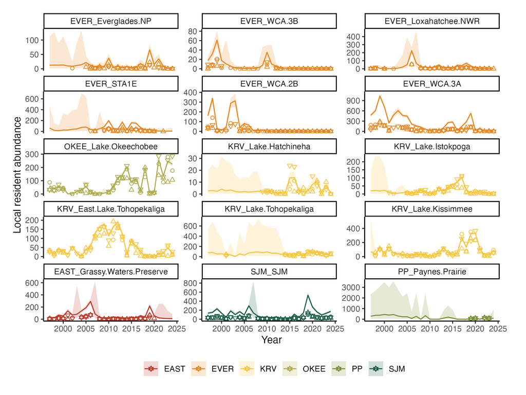

```r
kalman_wide$wetland <- factor(kalman_wide$wetland,
                             levels = c("EAST_Grassy.Waters.Preserve", # EAST
                                        "EVER_WCA.3A", # EVER
                                        "EVER_WCA.2B", # EVER
                                        "EVER_Loxahatchee.NWR", # EVER
                                        "EVER_WCA.3B", # EVER
                                        "EVER_Everglades.NP", # EVER
                                        "EVER_STA1E", # EVER
                                        "KRV_East.Lake.Tohopekaliga", # KRV
                                        "KRV_Lake.Kissimmee", # KRV
                                        "KRV_Lake.Istokpoga", # KRV
                                        "KRV_Lake.Hatchineha", # KRV
                                        "KRV_Lake.Tohopekaliga", # KRV
                                        "OKEE_Lake.Okeechobee", # OKEE
                                        "PP_Paynes.Prairie", # PP
                                        "SJM_SJM" # SJM
                                        ))

# Plot using ggplot2
Wetland_water_detectp <- ggplot(kalman_wide, aes(x = time, y = `50%`,
                        color = factor(region),
                        fill = factor(region))) +
  facet_wrap(~factor(wetland,
                     levels = c(
                       "EVER_Everglades.NP","EVER_WCA.3B","EVER_Loxahatchee.NWR",
                       "EVER_STA1E","EVER_WCA.2B","EVER_WCA.3A",
                       "OKEE_Lake.Okeechobee",
                       "KRV_Lake.Hatchineha","KRV_Lake.Istokpoga",
                       "KRV_East.Lake.Tohopekaliga",
                       "KRV_Lake.Tohopekaliga",
                       "KRV_Lake.Kissimmee",
                       "EAST_Grassy.Waters.Preserve",
                       "SJM_SJM",
                       "PP_Paynes.Prairie"
                       )),
             ncol = 3, scales = "free_y") +
  geom_line() +
  geom_ribbon(aes(ymin = `2.5%`, ymax = `97.5%`),
              alpha = 0.2, color = NA) +
  geom_point(aes(y = Count4), shape = 25, fill = NA)+
  geom_point(aes(y = Count5), shape = 21, fill = NA)+
  geom_point(aes(y = Count6), shape = 24, fill = NA)+
  labs(
    x = "Year",
    y = "Local resident abundance",
    color = "",
    fill = ""
    ) +
  scale_color_manual(values=met.brewer("Homer2", 6)) +
  scale_fill_manual(values=met.brewer("Homer2", 6)) +
  theme_classic() +
  theme(legend.position = "bottom",
        legend.direction = "horizontal",
        plot.margin = margin(0.5, 1, 0.5, 0.5, "cm")) +
  guides(color=guide_legend(nrow =1),
         fill=guide_legend(nrow = 1))

ggsave(Wetland_water_detectp, filename = "Wetland_15_water_phat.pdf",dpi = 300,
       width = 200, height = 150, units = "mm")
ggsave(Wetland_water_detectp, filename = "Wetland_15_water_phat.jpg",dpi = 300,
       width = 200, height = 150, units = "mm")
```

In this plot, the open points represent three surveys per year: down-facing triangles are survey 4, circles are survey 5, and up-facing triangles are survey 6. This dynamic includes the extra parameter for detectability and the influence of relative water sage as a quadratic effect. Using quadratic effect of water reduces the confidence intervals of predicted trajectories of the population.

[figure not shown]

# 3 How does a change in water level affects the growth rate of the different populations?

Our modified Gompertz model in full matrix format that includes standardized quadratic water level effects is:

$$\mathbf{X}_{t+1} = \mathbf{A} + \beta\mathbf{W}^2_t+ (\mathbf{I} + \mathbf{B})\mathbf{X}_t + \mathbf{E}_t$$
where $\mathbf{W}$ denotes the standardized water level as explained in the main text. The State-space model is completed by including the observation process, as a Poisson error with detection probability:

$$\mathbf{N}_{t} \sim \text{Poisson}(p_{t} \times e^{\mathbf{X}_{t}}).$$

The idea of including the effect of water levels in the growth rate is to be able to compare the estimated growth rate after accounting for the effect of water with the standard growth rate, a little bit like one would compare the reduction of the residual sum of squares brought about by an extra factor added to a regression model. From the initial model we have that

$$\begin{array}{lll}
\mathbf{X}_{t+1} &=& \mathbf{X}_t + \mathbf{A} + \mathbf{BX}_t + \mathbf{E}_t\\
&=& \mathbf{A} + (\mathbf{I} + \mathbf{B})\mathbf{X}_t + \mathbf{E}_t\quad\text{where}\quad\mathcal{B} = \mathbf{I}+ \mathbf{B}.
\end{array}$$
Hence, the growth rate $\text{R}_t$ is written as:
$$\begin{array}{lll}
\text{R}_t&=& \mathbf{X}_{t+1} - \mathbf{X}_t \\
&=& \mathbf{A} + \mathbf{BX}_t+\mathbf{E}_t \\
&=& \mathbf{A} + (\mathcal{B}-\mathbf{I})\mathbf{X}_t + \mathbf{E}_t.
\end{array}$$

With a water covariate effect, the growth rate becomes:

$$\text{R}_{t}^{W}= \mathbf{X}_{t+1} - \mathbf{X}_t = \mathbf{A} + \mathbf{BX}_t + \beta W_t^2 + \mathbf{E}_t.$$

Thus, to achieve a benchmark comparison with the model without a water covariate, we can simply subtract both growth rates which simply yields $\beta W^2$. Because that coefficient is assumed to be the same for all populations, scaling it by the vector of means $\boldsymbol{\mu} = \mathbf{(I-B)^{-1}A}$ allows one to compare visually how the water term affects the growth rate, with a fraction change $f$. Thus, we set the estimate of the water effects as:

$$\begin{array}
\hat{\mu_i} \times f &=& \frac{\hat{\beta}W_t^{2}}{\hat{\mu_i}} \\
f &=& \frac{\hat{\beta}W_t^{2}}{\hat{\mu_i}^{2}}.
\end{array}$$

where we abuse a bit of the vector notation and remark that the division in the above fraction represents element-wise division. Thus, $\boldsymbol{f}$ is a vector of estimated water effects per wetland studied. We emphasize that adopting this statistic to estimate the water effects is useful because it directly shows how the maximum growth rates, the strength of density dependence and the inter-demes effects $b_{ij}$ regulate the effect of water level changes in every deme. Finally, note that using the value of $\boldsymbol{\mu}$ to scale the water effect is also justified because it is the value of the process that renders the growth rate zero on average. To see why, recall that in the long-run, $\mathbf{X}_t = \mathbf{X}_{t+1} = \mathbf{X}_{\infty}$ is invariant over time so that the average growth rate is $\text{E}[\text{R}_t] = \mathbf{0} = \text{E}[\mathbf{A} + (\mathcal{B}-\mathbf{I})\mathbf{X}_\infty + \mathbf{E}_t]$. To check that this is true, note that the right hand side (RHS) of this last equation is $\mathbf{A} + (\mathcal{B}-\mathbf{I})\text{E}[\mathbf{X}_\infty] = \mathbf{A} + (\mathcal{B}-\mathbf{I})\boldsymbol{\mu}$ and since $\boldsymbol{\mu} = (\mathbf{I-B})^{-1}\mathbf{A}$ the last equation becomes $\mathbf{A} -\mathbf{IA} = \mathbf{0}$.

```r
# standardize growth rate changes per population
# ((A + BX - ßW)-(A + BX)) / (A + BX)
# ßW/(A+BX) # fraction of reduction in growth rate

# average growth rate (A+(B-I)X)
avg.gr <- muvec4kalman #avec4kalman + (B-diag(p)) %*% muvec4kalman

# Get a range of Water level (centered) for plotting
W.sim = seq(min(W),max(W),by = 0.01)
W.sim.sqr = W.sim^2

std.gr.hat <- matrix(0, nrow = length(W.sim), ncol = 15)
for (i in 1:15){
  #std.gr.hat[,i] <- (beta.4kalman * W.sim.sqr) / (avg.gr[i])
  std.gr.hat[,i] <- (beta.4kalman * W.sim.sqr) / (avg.gr[i]^2)
}

cool.palette <- as.vector(met.brewer("Signac",15))

wet.names
```

```
##  [1] "EAST_Grassy.Waters.Preserve" "EVER_WCA.3A"
##  [3] "EVER_WCA.2B"                 "EVER_Loxahatchee.NWR"
##  [5] "EVER_WCA.3B"                 "EVER_Everglades.NP"
##  [7] "EVER_STA1E"                  "KRV_East.Lake.Tohopekaliga"
##  [9] "KRV_Lake.Kissimmee"          "KRV_Lake.Istokpoga"
## [11] "KRV_Lake.Hatchineha"         "KRV_Lake.Tohopekaliga"
## [13] "OKEE_Lake.Okeechobee"        "PP_Paynes.Prairie"
## [15] "SJM_SJM"
```

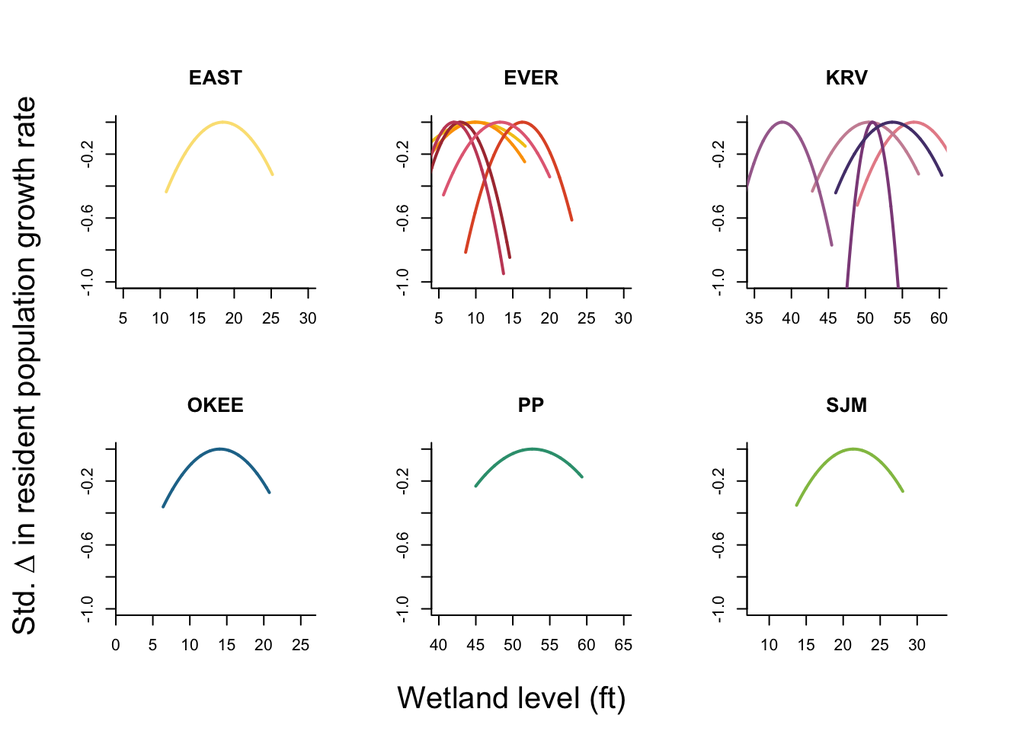

```r
#std.gr.hat <- mat.forlist

colnames(std.gr.hat) <- wet.names

mean_W_wetland <- daily_wetland_water |>
  group_by(region.wetland) |>
  summarize(mean_stage = mean(mean_stage, na.rm = TRUE)) |>
  as.data.frame()

mean_W4wetland <- matrix(NA,nrow = length(wet.names),ncol = 1)
for(i in 1:15){
mean_W4wetland[i] <- mean_W_wetland$mean_stage[mean_W_wetland$region.wetland == wet.names[i]]
}

par(mfrow=c(2,3), oma=c(2,2,2,2), mar=c(4,4,4,2))
plot(W.sim+mean_W4wetland[1], std.gr.hat[,1], col=cool.palette[1],
     type = "l",
     xlab="", ylab="",
     xlim = c(5,30),
     ylim=c(-1,0),
     bty="l", main="EAST", cex.main=1.25,lwd=2)
for(i in 2:7){
  if(i==2){
    plot(W.sim+mean_W4wetland[i],std.gr.hat[,i], type="l", col=cool.palette[i],
     xlim = c(5,30),
     ylim=c(-1,0),
     xlab="", ylab="",
     bty="l", main="EVER", cex.main=1.25,lwd=2)
   }
  else{
    points(W.sim+mean_W4wetland[i],std.gr.hat[,i], type="l", col=cool.palette[i],lwd=2)
  }
}
for(i in 8:12){
  if(i==8){
    plot(W.sim+mean_W4wetland[i],std.gr.hat[,i], type="l", col=cool.palette[i],
     xlim = c(35,60),
     ylim=c(-1,0),
     xlab="", ylab="",
     bty="l", main="KRV", cex.main=1.25,lwd=2)
   }
  else{
    points(W.sim+mean_W4wetland[i],std.gr.hat[,i], type="l", col=cool.palette[i],lwd=2)
  }
}
plot(W.sim+mean_W4wetland[13], std.gr.hat[,13], col=cool.palette[13],lwd=2,
     type = "l",
     xlim = c(1,26),
     xlab="", ylab="",  ylim=c(-1,0),
     bty="l", main="OKEE", cex.main=1.25)
plot(W.sim+mean_W4wetland[14], std.gr.hat[,14], col=cool.palette[14],lwd=2,
     type = "l",
     xlim = c(40,65),
     xlab="", ylab="",  ylim=c(-1,0),
     bty="l", main ="PP", cex.main=1.25)
plot(W.sim+mean_W4wetland[15], std.gr.hat[,15], col=cool.palette[15],lwd=2,
     type = "l",
     xlim = c(8,33),
     xlab="", ylab="",
     ylim=c(-1,0),
     bty="l", main="SJM", cex.main=1.25)

mtext("Wetland level (ft)", side=1, cex=1.25, outer=TRUE)
mtext("Std. ∆ in resident population growth rate",side=2, cex=1.25, outer=TRUE)
```

Next, we show the code to compute the confidence intervals for the parabolic curves shown in the previous plot:

```r
# create a Function to compute the
# standardized growth rate changes per population
# ((A + BX - ßW)-(A + BX)) / (A + BX)
# ßW/(A+BX) # fraction of reduction in growth rate

one.boot.quad.effect <- function(p, muvec4kalman, beta.4kalman){

  # average growth rate (A+(B-I)X)
  avg.gr <- muvec4kalman
  #avg.gr[avg.gr==0] <- .Machine$double.xmin
  #print(avg.gr)
  # Get a range of Water level (centered) for plotting
  W.sim = seq(min(W),max(W),by = 0.01)
  W.sim.sqr = W.sim^2

  std.gr.hat <- matrix(0, nrow = length(W.sim), ncol = 15)
  for (i in 1:15){
    std.gr.hat[,i] <- (beta.4kalman * W.sim.sqr) / (avg.gr[i]^2)
  }

  return(std.gr.hat)
}

# Pull back the MCMC chain only with the parameters I need

# Print these three lines to recall the structure of the MCMC chain
length(mgssdclone_w)
dim(mgssdclone_w[[1]])
colnames(mgssdclone_w[[1]])


NMCMC <- dim(mgssdclone_w[[1]])[1]

st.gr.boot.list <- list() #Here I will save 10000 std.gr.hats

inftest <- rep(0, NMCMC)
for(i in 1:NMCMC){

  # Retrieve the model parameters:
  beta.star <- mgssdclone_w[[1]][i,16]
  muvec.star <-   mgssdclone_w[[1]][i,34:48]

  mat.forlist <- one.boot.quad.effect(p=p,
                                      muvec4kalman=muvec.star,
                                      beta.4kalman=beta.star)
  st.gr.boot.list[[i]] <- mat.forlist
  notinf <- sum(is.infinite(mat.forlist))<1

  inftest[i] <- notinf

}

# Test plot
# par(mfrow=c(1,1), oma=c(2,2,2,2), mar=c(4,4,4,2))
# plot(W.sim, std.gr.hat[,1], col=cool.palette[1],
#      type = "l",
#      xlab="", ylab="",
#      xlim = c(min(W),max(W)),ylim=c(-2,0),
#      bty="l", main="EAST", cex.main=1.25,lwd=2)
# for(i in 1:NMCMC){
#   points(W.sim, st.gr.boot.list[[i]][,1],col=scales::alpha(cool.palette[1],0.01),
#      type = "l")
# }

saveRDS(st.gr.boot.list, file="Code/stgrbootlist_15wetlands.RDS")
```

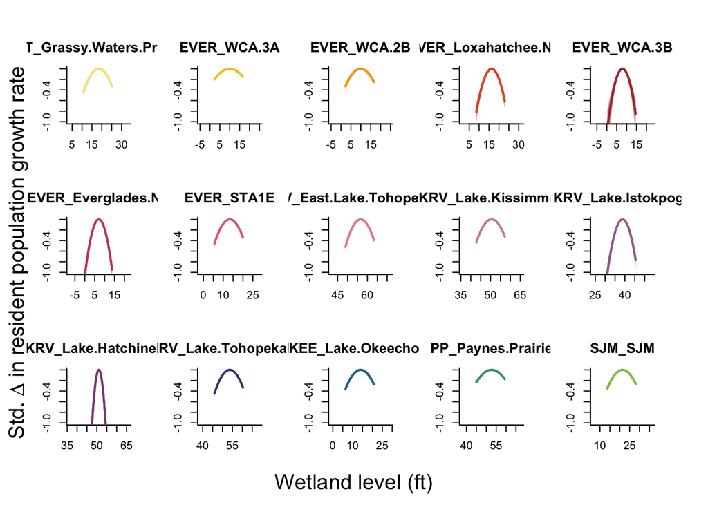

```r
st.gr.boot.list <- readRDS(file="Code/stgrbootlist_15wetlands.RDS")
# Re-organizing the 10,000 list into 11 matrices each with 10,000 columns

NMCMC <- dim(mgssdclone_w[[1]])[1]

std.gr.15.mats <- list()
for(i in 1:15){
  ith.of15.bootmat <- matrix(0,nrow=length(W.sim), ncol=NMCMC)
  for(j in 1:NMCMC){
    ith.of15.bootmat[,j] <- st.gr.boot.list[[j]][,i]
  }
  std.gr.15.mats[[i]] <- ith.of15.bootmat
}


# Maybe it's better to save the 15 matrices of quantiles as well:

quants4.15.mats <- list()
for(i in 1:15){
  quants4.15.mats[[i]] <- apply(std.gr.15.mats[[i]], 1,
                                FUN=function(x){quantile(x, probs=c(0.025,0.5,0.975))})
}


par(mfrow=c(3,5), oma=c(2,2,2,2), mar=c(4,3,3,2))
for(i in 1:15){
  plot(W.sim+mean_W4wetland[i], std.gr.hat[,i], col=cool.palette[i],
       type = "l",
       xlab="", ylab="",
       xlim = c(mean_W4wetland[i]-15,mean_W4wetland[i]+15),ylim=c(-1,0),
       bty="l", main=wet.names[i], cex.main=1.25,lwd=2)
  polygon(c(W.sim+mean_W4wetland[i],rev(W.sim+mean_W4wetland[i])),
          c(quants4.15.mats[[i]][1,],
            rev(quants4.15.mats[[i]][3,])),
          col=scales::alpha(cool.palette[i],0.5), border=NA)
  points(W.sim+mean_W4wetland[i], std.gr.hat[,i], col=cool.palette[i],
       type = "l", lwd=2)
}
mtext("Wetland level (ft)", side=1, cex=1.25, outer=TRUE)
mtext("Std. ∆ in resident population growth rate",side=2, cex=1.25, outer=TRUE)
```

Organizing the figure form the more sensible (lower $\hat{\mu}$) to the less sensible (biggest $\hat{\mu}$)

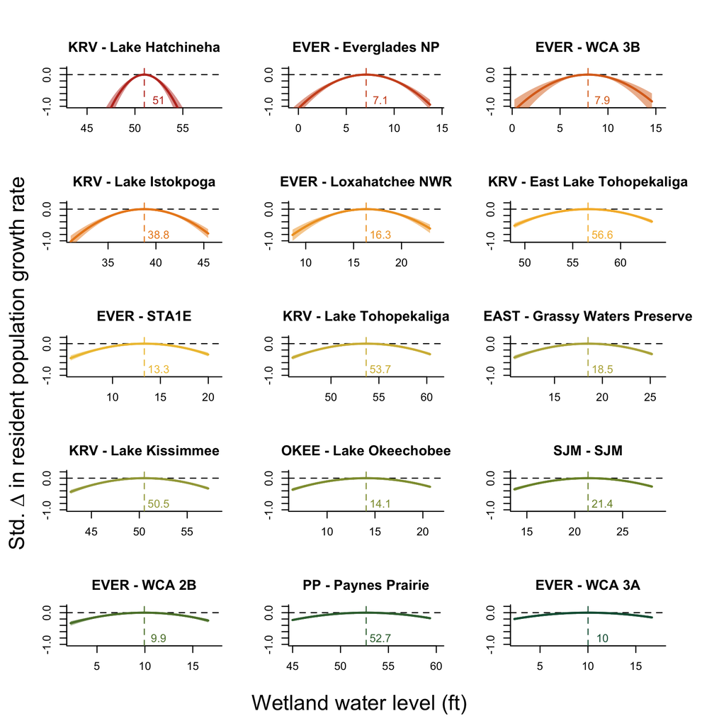

```r
sensible <- c(11,6,5,10,4,8,7,12,1,9,13,15,3,14,2)

wet.names <- gsub("[_]", " - ", wet.names)
wet.names <- gsub("[.]", " ", wet.names)

sensi.palette <- as.vector(met.brewer("Homer2",15))
counter <- 1
par(mfrow=c(5,3), oma=c(2,2,2,2), mar=c(4,3,3,2))
for(i in sensible){
  plot(W.sim+mean_W4wetland[i], std.gr.hat[,i], col=sensi.palette[counter],
       type = "l",
       xlab="", ylab="",
       xlim = c(mean_W4wetland[i]-7.5,mean_W4wetland[i]+7.5),
       ylim=c(-1,0.2),
       bty="l", main=wet.names[i], cex.main=1.25,lwd=2)
    abline(h = 0, lty = 2)
  polygon(c(W.sim+mean_W4wetland[i],rev(W.sim+mean_W4wetland[i])),
          c(quants4.15.mats[[i]][1,],
            rev(quants4.15.mats[[i]][3,])),
          col=scales::alpha(sensi.palette[counter],0.5), border=NA)
  points(W.sim+mean_W4wetland[i], std.gr.hat[,i], col=sensi.palette[counter],
       type = "l", lwd=2)
  abline(v = mean_W4wetland[i], lty = 2, col = sensi.palette[counter])
  text(mean_W4wetland[i]+1.5, -0.8, round(mean_W4wetland[i], 1), col = sensi.palette[counter])
  counter <- counter + 1
}
mtext("Wetland water level (ft)", side=1, cex=1.25, outer=TRUE)
mtext("Std. ∆ in resident population growth rate",side=2, cex=1.25, outer=TRUE)
```

# 4 How will this affect the next step estimation?

We cannot project to many years ahead the model, because the covariates messed with the stationary definition. But we can model the next step and the changes in relative water level.

Let’s bring the last point estimation per wetland:

```r
len <- ncol(S4mat)

names.quants.1 <- substr(colnames(Kalman.quants.w), start=1, stop=3)
names.quants.2 <- substr(colnames(Kalman.quants.w), start=1, stop=4)
X1s <- Kalman.quants.w[,which(names.quants.1=="X[1", arr.ind=TRUE)]
X2s <- Kalman.quants.w[,which(names.quants.1=="X[2", arr.ind=TRUE)]
X3s <- Kalman.quants.w[,which(names.quants.1=="X[3", arr.ind=TRUE)]
X4s <- Kalman.quants.w[,which(names.quants.1=="X[4", arr.ind=TRUE)]
X5s <- Kalman.quants.w[,which(names.quants.1=="X[5", arr.ind=TRUE)]
X6s <- Kalman.quants.w[,which(names.quants.1=="X[6", arr.ind=TRUE)]
X7s <- Kalman.quants.w[,which(names.quants.1=="X[7", arr.ind=TRUE)]
X8s <- Kalman.quants.w[,which(names.quants.1=="X[8", arr.ind=TRUE)]
X9s <- Kalman.quants.w[,which(names.quants.1=="X[9", arr.ind=TRUE)]
X10s <- Kalman.quants.w[,which(names.quants.2=="X[10", arr.ind=TRUE)]
X11s <- Kalman.quants.w[,which(names.quants.2=="X[11", arr.ind=TRUE)]
X12s <- Kalman.quants.w[,which(names.quants.2=="X[12", arr.ind=TRUE)]
X13s <- Kalman.quants.w[,which(names.quants.2=="X[13", arr.ind=TRUE)]
X14s <- Kalman.quants.w[,which(names.quants.2=="X[14", arr.ind=TRUE)]
X15s <- Kalman.quants.w[,which(names.quants.2=="X[15", arr.ind=TRUE)]
```

We can estimate the change in abundance distribution with change in relative water. Given that it is a relative value centered around 0, multiply by a percentage of change change mainly the spread of the data, but little change in mean value (from `green` to `red` or `blue`:

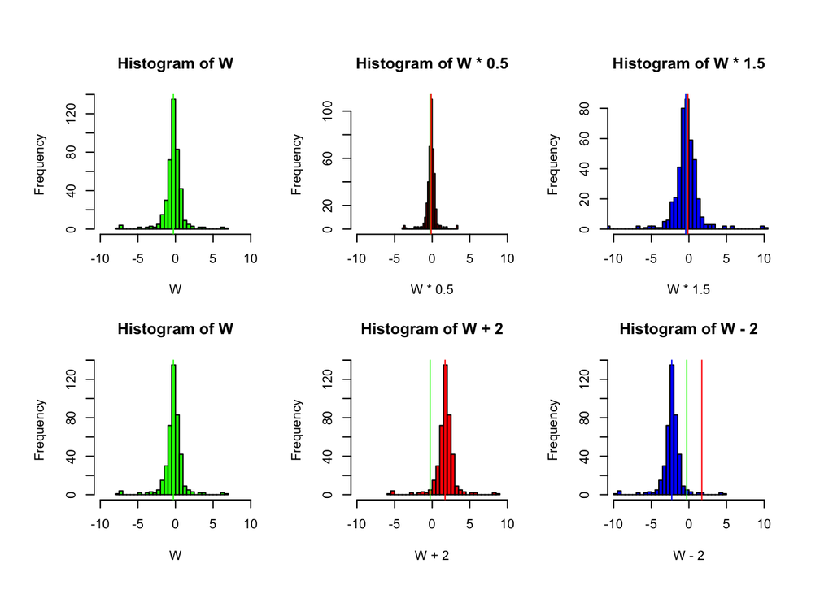

```r
par(mfrow=c(2,3), oma=c(2,2,2,2), mar=c(4,4,4,2))

hist(W, breaks = 50, xlim = c(-10,10), col = "green")
abline(v = mean(W), col = "green")

hist(W*0.5, breaks = 50, xlim = c(-10,10), col = "red")
abline(v = mean(W), col = "green")
abline(v = mean(W*0.5), col = "red")

hist(W*1.5, breaks = 50, xlim = c(-10,10), col = "blue")
abline(v = mean(W), col = "green")
abline(v = mean(W*0.5), col = "red")
abline(v = mean(W*1.5), col = "blue")

hist(W, breaks = 50, xlim = c(-10,10), col = "green")
abline(v = mean(W), col = "green")

hist(W+2, breaks = 50, xlim = c(-10,10), col = "red")
abline(v = mean(W), col = "green")
abline(v = mean(W+2), col = "red")

hist(W-2, breaks = 50, xlim = c(-10,10), col = "blue")
abline(v = mean(W), col = "green")
abline(v = mean(W+2), col = "red")
abline(v = mean(W-2), col = "blue")
```

But we can add specific values of change in relative water, assuming change in values but not in spread

Thus, we can simulate the next point with the quadratic relationship of Relative water (stage)

```r
MVX.sim <- function(
    xo.vec = c(X1s[2,28],
               X2s[2,28],X3s[2,28],X4s[2,28],X5s[2,28],X6s[2,28],X7s[2,28],
               X8s[2,28],X9s[2,28],X10s[2,28],X11s[2,28],X12s[2,28],
               X13s[2,28],
               X14s[2,28],
               X15s[2,28]),
    W = W[,28],
    theta.list = list(p=p,
                      Ip =  diag(p),
                      muvec = muvec4kalman,
                      sigmasq = sigsq4kalman,
                      B = B,
                      beta = beta.4kalman),
    rnames = row.names(S4mat),
    Nsims = 10,
    pt.change = 1
    ){
  W <- (W+pt.change)^2 #change in value of Water, but quadratic effect
  p  <- theta.list$p
  Ip <- theta.list$Ip
  muvec <- theta.list$muvec
  sigmasq <- theta.list$sigmasq
  B <- theta.list$B
  beta <- theta.list$beta

  A  <- (Ip - B)%*%muvec
  Sigma <- (1/sigmasq)*Ip

    ## Process error
    X <- randmvn(n=Nsims,
                 mu.vec=A + beta*W + B%*%xo.vec, cov.mat=Sigma)

  #X <- cbind(xo.vec,X)
  row.names(X) <- rnames
  colnames(X) <- 1:Nsims
  return(X)
}
```

And we can try different values, like above the Relative stage values in Fig. 4b of [Fletcher et al. 2021](https://doi.org/10.1016/j.biocon.2020.108893).

```r
probs.change.list <- list()
changes <- seq(5,-5, by=-2.5)
nchanges <- length(changes)

for(i in 1:nchanges){
  probs.change.list[[i]] <- MVX.sim(
    xo.vec = c(X1s[2,28],
               X2s[2,28],X3s[2,28],X4s[2,28],X5s[2,28],X6s[2,28],X7s[2,28],
               X8s[2,28],X9s[2,28],X10s[2,28],X11s[2,28],X12s[2,28],
               X13s[2,28],
               X14s[2,28],
               X15s[2,28]),
               W = W[,28],
    theta.list = list(p=p,
                      Ip =  diag(p),
                      muvec = muvec4kalman,
                      sigmasq = sigsq4kalman,
                      B = B,
                      beta = beta.4kalman),
    rnames = row.names(S4mat),
    Nsims = 100000,
    pt.change = changes[i])
}
names(probs.change.list) <- as.character(sprintf("%.1f", changes))
```

```r
probs.change.df <- bind_rows(
  lapply(names(probs.change.list), function(name) {
    df <- as.data.frame(probs.change.list[[name]])
    # Save row names as a column
    df$wetland <- rownames(probs.change.list[[name]])
    # Add the original name as a column
    df$change <- paste0("∆ ",name)
    return(df)
  }),
  .id = "id"  # Optional: adds an index column
)

table(probs.change.df$change)
```

```
##
## ∆ -2.5 ∆ -5.0  ∆ 0.0  ∆ 2.5  ∆ 5.0
##     15     15     15     15     15
```

```r
probs.change.df.long <- probs.change.df |>
  dplyr::select(!c(id)) |>
  pivot_longer(-c(wetland,change),
               names_to = "P.change_Sim",
               values_to = "mu")

probs.change.df.long$change <- factor(probs.change.df.long$change,
                                      levels = c("∆ 5.0",
                                                 "∆ 2.5",
                                                 "∆ 0.0",
                                                 "∆ -2.5",
                                                 "∆ -5.0"))
```

And make the density plots

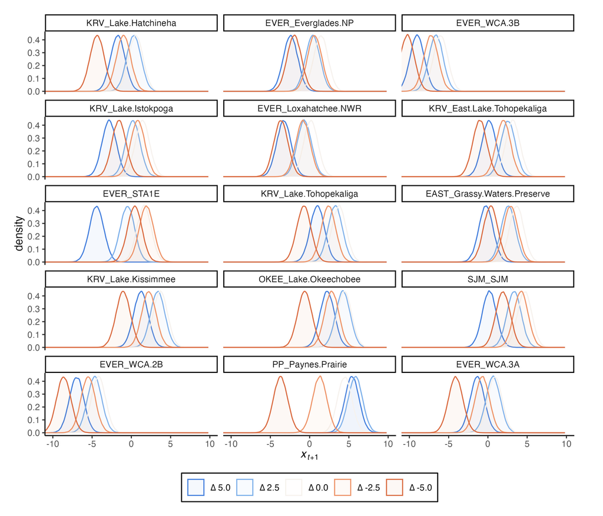

```r
change.water.log <- probs.change.df.long |>
  ggplot(aes(x = mu,
           color = factor(change),
           fill = factor(change)))+
  facet_wrap(~factor(wetland,
                     levels = c(
                       "KRV_Lake.Hatchineha","EVER_Everglades.NP","EVER_WCA.3B",
                       "KRV_Lake.Istokpoga","EVER_Loxahatchee.NWR", "KRV_East.Lake.Tohopekaliga",
                       "EVER_STA1E","KRV_Lake.Tohopekaliga","EAST_Grassy.Waters.Preserve",
                       "KRV_Lake.Kissimmee","OKEE_Lake.Okeechobee","SJM_SJM",
                       "EVER_WCA.2B","PP_Paynes.Prairie","EVER_WCA.3A"
                       )),
             ncol = 3)+
  geom_density(alpha = 0.05, position = "dodge")+
#  geom_density_ridges(rel_min_height = 0.01,
#                      alpha = 0.05, scale = 0.9, jittered_points = FALSE,
#                      position = position_points_jitter(width = 0.05, height = 0))+
  scale_color_manual(values=rev(met.brewer("OKeeffe1",n = nchanges))) +
  scale_fill_manual(values=rev(met.brewer("OKeeffe1",n = nchanges))) +
  labs(x = expression(italic(x)[italic(t)+1]))+
  theme_classic()+
  theme(legend.position = "bottom",
        legend.title = element_blank(),
        legend.background = element_rect(fill="white",
                                  linewidth=0.5, linetype="solid",
                                  colour ="black"),
        plot.margin = margin(0.5, 1, 0.5, 0.5, "cm"))+
  guides(color=guide_legend(nrow =1),
         fill=guide_legend(nrow = 1)) +
  coord_cartesian(xlim = c(-10,10))

ggsave(change.water.log, filename = "Changes in log-ab one step.jpg",dpi = 300,
       width = 210, height = 180, units = "mm")
```

But the previous figure is only one step, from the current year. If we want to compare across populations this effect, we can use as start point the mean expected $\hat{\mu}$ from the overall trajectory

```r
probs.change.list.mu <- list()
changes <- seq(5,-5, by=-2.5)
nchanges <- length(changes)

for(i in 1:nchanges){
  probs.change.list.mu[[i]] <- MVX.sim(
    xo.vec = c(muvec4kalman),
               W = W[,28],
    theta.list = list(p=p,
                      Ip =  diag(p),
                      muvec = muvec4kalman,
                      sigmasq = sigsq4kalman,
                      B = B,
                      beta = beta.4kalman),
    rnames = row.names(S4mat),
    Nsims = 100000,
    pt.change = changes[i])
}
names(probs.change.list.mu) <- as.character(sprintf("%.1f", changes))

probs.change.df.mu <- bind_rows(
  lapply(names(probs.change.list.mu), function(name) {
    df <- as.data.frame(probs.change.list.mu[[name]])
    # Save row names as a column
    df$wetland <- rownames(probs.change.list.mu[[name]])
    # Add the original name as a column
    df$change <- paste0("∆ ",name)
    return(df)
  }),
  .id = "id"  # Optional: adds an index column
)

table(probs.change.df.mu$change)
```

```
##
## ∆ -2.5 ∆ -5.0  ∆ 0.0  ∆ 2.5  ∆ 5.0
##     15     15     15     15     15
```

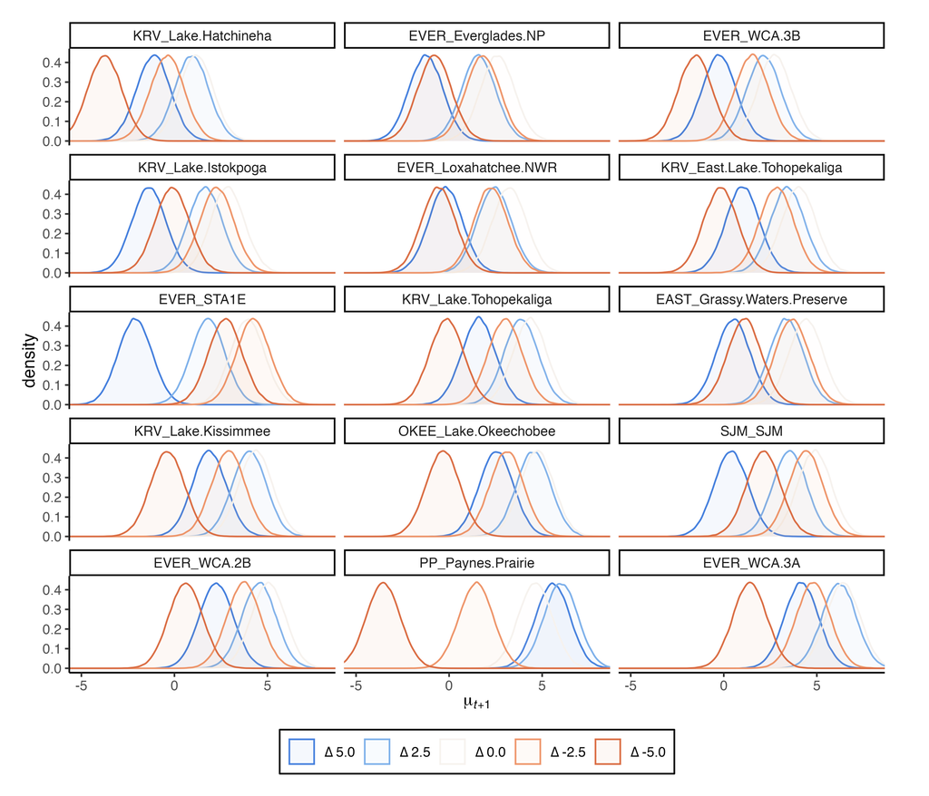

Change in expected abundance (log-scale) with change in relative water (stage) values, starting from the mean abundance at each wetland

```r
probs.change.df.long.mu <- probs.change.df.mu |>
  dplyr::select(!c(id)) |>
  pivot_longer(-c(wetland,change),
               names_to = "P.change_Sim",
               values_to = "mu")

probs.change.df.long.mu$change <- factor(probs.change.df.long.mu$change,
                                      levels = c("∆ 5.0",
                                                 "∆ 2.5",
                                                 "∆ 0.0",
                                                 "∆ -2.5",
                                                 "∆ -5.0"))

change.water.log.mu <- probs.change.df.long.mu |>
  ggplot(aes(x = mu,
           color = factor(change),
           fill = factor(change)))+
  facet_wrap(~factor(wetland,
                     levels = c(
                       "KRV_Lake.Hatchineha","EVER_Everglades.NP","EVER_WCA.3B",
                       "KRV_Lake.Istokpoga","EVER_Loxahatchee.NWR", "KRV_East.Lake.Tohopekaliga",
                       "EVER_STA1E","KRV_Lake.Tohopekaliga","EAST_Grassy.Waters.Preserve",
                       "KRV_Lake.Kissimmee","OKEE_Lake.Okeechobee","SJM_SJM",
                       "EVER_WCA.2B","PP_Paynes.Prairie","EVER_WCA.3A"
                       )), ncol = 3)+
  geom_density(alpha = 0.05, position = "dodge")+
#  geom_density_ridges(rel_min_height = 0.01,
#                      alpha = 0.05, scale = 0.9, jittered_points = FALSE,
#                      position = position_points_jitter(width = 0.05, height = 0))+
  scale_color_manual(values=rev(met.brewer("OKeeffe1",n = nchanges))) +
  scale_fill_manual(values=rev(met.brewer("OKeeffe1",n = nchanges))) +
  labs(x = expression(mu[italic(t)+1]))+
  theme_classic()+
  theme(legend.position = "bottom",
        legend.direction = "vertical",
        legend.title = element_blank(),
        legend.background = element_rect(fill="white",
                                  linewidth=0.5, linetype="solid",
                                  colour ="black"),
        plot.margin = margin(0.5, 1, 0.5, 0.5, "cm"))+
  guides(color=guide_legend(nrow =1),
         fill=guide_legend(nrow=1)) +
  coord_cartesian(xlim = c(-5,8))

ggsave(change.water.log.mu, filename = "Changes in mu one step.jpg",dpi = 600,
       width = 210, height = 180, units = "mm")
ggsave(change.water.log.mu, filename = "Changes in mu one step.png",dpi = 600,
       width = 210, height = 180, units = "mm")
```